# Time Series Data

[figure not shown]

.................................................... start of document ....................................................

## Synopsis

**Terms**

- **Time Series Data:** The order of observations in **time series data** is significant. In general, data analytic methods do not work on time series data because they do not respect the order of observations.
- **Cross-Sectional Data:** The order of observations in **cross-sectional data** is not significant. In general, data analytic methods do work on cross-sectional data.
- **Time Variable:** A variable (if it exists) that indexes the order of time series data.
- **Viewpoint:** The time step at which a prediction is made about subsequent time steps.
- **View:** An observation comprising variables with information about prior time steps, a viewpoint, and/or subsequent time steps.

## Exposition

### Data

| observations | variables |
| --- | --- |
| 396 | 2 |

| day | outcome |
| --- | --- |
| 2013-01-01 | 58713.65 |
| 2013-01-02 | 59471.86 |
| 2013-01-03 | 56288.03 |
| 2013-01-04 | 56493.22 |
| 2013-01-05 | 57717.88 |
| 2013-01-06 | 61021.22 |
| 2013-01-07 | 57471.34 |
| 2013-01-08 | 55542.50 |
| 2013-01-09 | 56025.00 |
| 2013-01-10 | 59837.13 |
| 2013-01-11 | 59899.84 |
| 2013-01-12 | 64331.53 |
| 2013-01-13 | 67181.27 |
| 2013-01-14 | 65087.37 |
| 2013-01-15 | 63969.29 |
| 2013-01-16 | 64918.72 |
| 2013-01-17 | 65561.24 |
| 2013-01-18 | 69206.19 |
| 2013-01-19 | 72263.79 |
| 2013-01-20 | 73890.93 |
| 2013-01-21 | 67272.85 |
| 2013-01-22 | 66812.93 |
| 2013-01-23 | 65959.22 |
| 2013-01-24 | 65976.11 |
| 2013-01-25 | 66247.17 |
| 2013-01-26 | 63145.95 |
| 2013-01-27 | 63574.35 |
| 2013-01-28 | 60822.55 |
| 2013-01-29 | 57273.14 |
| 2013-01-30 | 54624.29 |
| ... | ... |
| 2014-01-02 | 55752.44 |
| 2014-01-03 | 57175.36 |
| 2014-01-04 | 59471.32 |
| 2014-01-05 | 62683.80 |
| 2014-01-06 | 56635.26 |
| 2014-01-07 | 55872.08 |
| 2014-01-08 | 54807.42 |
| 2014-01-09 | 55200.95 |
| 2014-01-10 | 55887.59 |
| 2014-01-11 | 57210.81 |
| 2014-01-12 | 63345.95 |
| 2014-01-13 | 56440.62 |
| 2014-01-14 | 56273.76 |
| 2014-01-15 | 55606.35 |
| 2014-01-16 | 54412.88 |
| 2014-01-17 | 55323.51 |
| 2014-01-18 | 57334.98 |
| 2014-01-19 | 52766.48 |
| 2014-01-20 | 56708.67 |
| 2014-01-21 | 56494.39 |
| 2014-01-22 | 55230.73 |
| 2014-01-23 | 56251.35 |
| 2014-01-24 | 56789.34 |
| 2014-01-25 | 57700.93 |
| 2014-01-26 | 63298.91 |
| 2014-01-27 | 58415.59 |
| 2014-01-28 | 56354.69 |
| 2014-01-29 | 58649.02 |
| 2014-01-30 | 58043.35 |
| 2014-01-31 | 58931.79 |

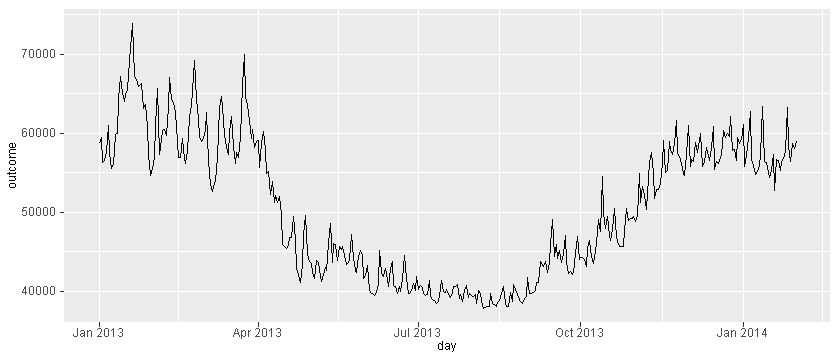

### Classical Approach

Prediction by the classical method uses one model to predict various numbers of time steps ahead of a static viewpoint. It treats the time variable as a numeric variable.

#### Prepare Time Series Data

Here we add a synthetic numeric variable corresponding to the time variable. The data's earliest time coincides with numeric value 1.

| observations | variables |
| --- | --- |
| 396 | 3 |

| day | step | outcome |
| --- | --- | --- |
| 2013-01-01 | 1 | 58713.65 |
| 2013-01-02 | 2 | 59471.86 |
| 2013-01-03 | 3 | 56288.03 |
| 2013-01-04 | 4 | 56493.22 |
| 2013-01-05 | 5 | 57717.88 |
| 2013-01-06 | 6 | 61021.22 |
| 2013-01-07 | 7 | 57471.34 |
| 2013-01-08 | 8 | 55542.50 |
| 2013-01-09 | 9 | 56025.00 |
| 2013-01-10 | 10 | 59837.13 |
| 2013-01-11 | 11 | 59899.84 |
| 2013-01-12 | 12 | 64331.53 |
| 2013-01-13 | 13 | 67181.27 |
| 2013-01-14 | 14 | 65087.37 |
| 2013-01-15 | 15 | 63969.29 |
| 2013-01-16 | 16 | 64918.72 |
| 2013-01-17 | 17 | 65561.24 |
| 2013-01-18 | 18 | 69206.19 |
| 2013-01-19 | 19 | 72263.79 |
| 2013-01-20 | 20 | 73890.93 |
| 2013-01-21 | 21 | 67272.85 |
| 2013-01-22 | 22 | 66812.93 |
| 2013-01-23 | 23 | 65959.22 |
| 2013-01-24 | 24 | 65976.11 |
| 2013-01-25 | 25 | 66247.17 |
| 2013-01-26 | 26 | 63145.95 |
| 2013-01-27 | 27 | 63574.35 |
| 2013-01-28 | 28 | 60822.55 |
| 2013-01-29 | 29 | 57273.14 |
| 2013-01-30 | 30 | 54624.29 |
| ... | ... | ... |
| 2014-01-02 | 367 | 55752.44 |
| 2014-01-03 | 368 | 57175.36 |
| 2014-01-04 | 369 | 59471.32 |
| 2014-01-05 | 370 | 62683.80 |
| 2014-01-06 | 371 | 56635.26 |
| 2014-01-07 | 372 | 55872.08 |
| 2014-01-08 | 373 | 54807.42 |
| 2014-01-09 | 374 | 55200.95 |
| 2014-01-10 | 375 | 55887.59 |
| 2014-01-11 | 376 | 57210.81 |
| 2014-01-12 | 377 | 63345.95 |
| 2014-01-13 | 378 | 56440.62 |
| 2014-01-14 | 379 | 56273.76 |
| 2014-01-15 | 380 | 55606.35 |
| 2014-01-16 | 381 | 54412.88 |
| 2014-01-17 | 382 | 55323.51 |
| 2014-01-18 | 383 | 57334.98 |
| 2014-01-19 | 384 | 52766.48 |
| 2014-01-20 | 385 | 56708.67 |
| 2014-01-21 | 386 | 56494.39 |
| 2014-01-22 | 387 | 55230.73 |
| 2014-01-23 | 388 | 56251.35 |
| 2014-01-24 | 389 | 56789.34 |
| 2014-01-25 | 390 | 57700.93 |
| 2014-01-26 | 391 | 63298.91 |
| 2014-01-27 | 392 | 58415.59 |
| 2014-01-28 | 393 | 56354.69 |
| 2014-01-29 | 394 | 58649.02 |
| 2014-01-30 | 395 | 58043.35 |
| 2014-01-31 | 396 | 58931.79 |

#### Partition Time Series Data for Training & Testing

Training data must comprise a sequence of observations corresponding to adjecent time steps.

Testing data must comprise a sequence of observations corresponding to adjecent time steps.

Here training data is for one year January 1, 2013 through December 31, 2013. Testing data is for one month January 1, 2014 through January 31, 2014.

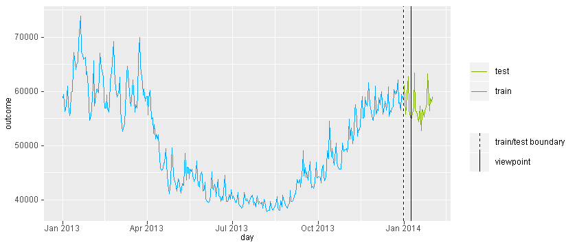

#### Model

Here we construct a linear regression model (with 4th degree polynomial transformation) to predict outcome given a time step.

|  | model.coefficients |
| --- | --- |
| (Intercept) | 59531.4166260292 |
| poly(step, 4, raw = TRUE)1 | 242.7584252609 |
| poly(step, 4, raw = TRUE)2 | -5.0708038387 |
| poly(step, 4, raw = TRUE)3 | 0.0222099086 |
| poly(step, 4, raw = TRUE)4 | -0.0000277999 |

#### Prediction

Here we choose a viewpoint of day 373 (2014-01-08).

| viewpoint |
| --- |
| 373 |

Use the model to predict outcome 1, 2, 3 days ahead of the viewpoint.

| day | step | outcome | outcome.predicted |
| --- | --- | --- | --- |
| 2014-01-01 | 366 | 61084.10 | NA |
| 2014-01-02 | 367 | 55752.44 | NA |
| 2014-01-03 | 368 | 57175.36 | NA |
| 2014-01-04 | 369 | 59471.32 | NA |
| 2014-01-05 | 370 | 62683.80 | NA |
| 2014-01-06 | 371 | 56635.26 | NA |
| 2014-01-07 | 372 | 55872.08 | NA |
| 2014-01-08 | 373 | 54807.42 | NA |
| 2014-01-09 | 374 | 55200.95 | 59006.82 |
| 2014-01-10 | 375 | 55887.59 | 58955.77 |
| 2014-01-11 | 376 | 57210.81 | 58897.62 |
| 2014-01-12 | 377 | 63345.95 | NA |
| 2014-01-13 | 378 | 56440.62 | NA |
| 2014-01-14 | 379 | 56273.76 | NA |
| 2014-01-15 | 380 | 55606.35 | NA |
| 2014-01-16 | 381 | 54412.88 | NA |
| 2014-01-17 | 382 | 55323.51 | NA |
| 2014-01-18 | 383 | 57334.98 | NA |
| 2014-01-19 | 384 | 52766.48 | NA |
| 2014-01-20 | 385 | 56708.67 | NA |
| 2014-01-21 | 386 | 56494.39 | NA |
| 2014-01-22 | 387 | 55230.73 | NA |
| 2014-01-23 | 388 | 56251.35 | NA |
| 2014-01-24 | 389 | 56789.34 | NA |
| 2014-01-25 | 390 | 57700.93 | NA |
| 2014-01-26 | 391 | 63298.91 | NA |
| 2014-01-27 | 392 | 58415.59 | NA |
| 2014-01-28 | 393 | 56354.69 | NA |
| 2014-01-29 | 394 | 58649.02 | NA |
| 2014-01-30 | 395 | 58043.35 | NA |
| 2014-01-31 | 396 | 58931.79 | NA |

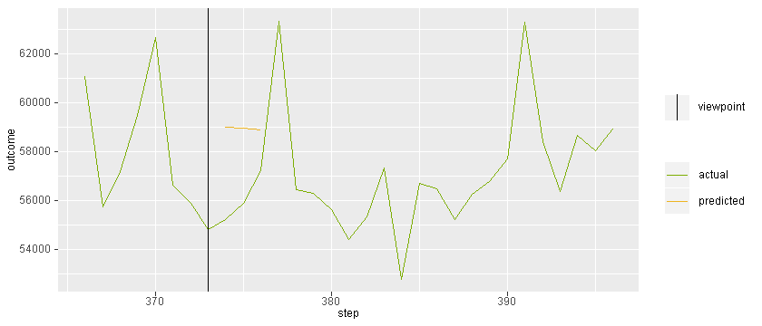

### Direct Approach

The direct approach uses several models to predict various numbers of time steps ahead of a static viewpoint.

#### Partition Time Series Data for Training & Testing

#### Further Prepare Training Data: Convert from Time Series Form to Cross-Sectional Form

Time series data can be converted to cross-sectional data, given a set of **lookbacks** and a set of **lookaheads**.

Here we choose these lookbacks and lookaheads:

- lookbacks: 0, 1, 2, 3, 4, 5, 6, 7 days
- lookaheads: 1, 2, 3 days (3 day horizon starting at 1 day ahead)

| observations | variables |
| --- | --- |
| 365 | 9 |

| day | outcome | lookback.1 | lookback.2 | lookback.3 | lookback.4 | lookback.5 | lookback.6 | lookback.7 |
| --- | --- | --- | --- | --- | --- | --- | --- | --- |
| 2013-01-01 | 58713.65 | NA | NA | NA | NA | NA | NA | NA |
| 2013-01-02 | 59471.86 | 58713.65 | NA | NA | NA | NA | NA | NA |
| 2013-01-03 | 56288.03 | 59471.86 | 58713.65 | NA | NA | NA | NA | NA |
| 2013-01-04 | 56493.22 | 56288.03 | 59471.86 | 58713.65 | NA | NA | NA | NA |
| 2013-01-05 | 57717.88 | 56493.22 | 56288.03 | 59471.86 | 58713.65 | NA | NA | NA |
| 2013-01-06 | 61021.22 | 57717.88 | 56493.22 | 56288.03 | 59471.86 | 58713.65 | NA | NA |
| 2013-01-07 | 57471.34 | 61021.22 | 57717.88 | 56493.22 | 56288.03 | 59471.86 | 58713.65 | NA |
| 2013-01-08 | 55542.50 | 57471.34 | 61021.22 | 57717.88 | 56493.22 | 56288.03 | 59471.86 | 58713.65 |
| 2013-01-09 | 56025.00 | 55542.50 | 57471.34 | 61021.22 | 57717.88 | 56493.22 | 56288.03 | 59471.86 |
| 2013-01-10 | 59837.13 | 56025.00 | 55542.50 | 57471.34 | 61021.22 | 57717.88 | 56493.22 | 56288.03 |
| 2013-01-11 | 59899.84 | 59837.13 | 56025.00 | 55542.50 | 57471.34 | 61021.22 | 57717.88 | 56493.22 |
| 2013-01-12 | 64331.53 | 59899.84 | 59837.13 | 56025.00 | 55542.50 | 57471.34 | 61021.22 | 57717.88 |
| 2013-01-13 | 67181.27 | 64331.53 | 59899.84 | 59837.13 | 56025.00 | 55542.50 | 57471.34 | 61021.22 |
| 2013-01-14 | 65087.37 | 67181.27 | 64331.53 | 59899.84 | 59837.13 | 56025.00 | 55542.50 | 57471.34 |
| 2013-01-15 | 63969.29 | 65087.37 | 67181.27 | 64331.53 | 59899.84 | 59837.13 | 56025.00 | 55542.50 |
| 2013-01-16 | 64918.72 | 63969.29 | 65087.37 | 67181.27 | 64331.53 | 59899.84 | 59837.13 | 56025.00 |
| 2013-01-17 | 65561.24 | 64918.72 | 63969.29 | 65087.37 | 67181.27 | 64331.53 | 59899.84 | 59837.13 |
| 2013-01-18 | 69206.19 | 65561.24 | 64918.72 | 63969.29 | 65087.37 | 67181.27 | 64331.53 | 59899.84 |
| 2013-01-19 | 72263.79 | 69206.19 | 65561.24 | 64918.72 | 63969.29 | 65087.37 | 67181.27 | 64331.53 |
| 2013-01-20 | 73890.93 | 72263.79 | 69206.19 | 65561.24 | 64918.72 | 63969.29 | 65087.37 | 67181.27 |
| 2013-01-21 | 67272.85 | 73890.93 | 72263.79 | 69206.19 | 65561.24 | 64918.72 | 63969.29 | 65087.37 |
| 2013-01-22 | 66812.93 | 67272.85 | 73890.93 | 72263.79 | 69206.19 | 65561.24 | 64918.72 | 63969.29 |
| 2013-01-23 | 65959.22 | 66812.93 | 67272.85 | 73890.93 | 72263.79 | 69206.19 | 65561.24 | 64918.72 |
| 2013-01-24 | 65976.11 | 65959.22 | 66812.93 | 67272.85 | 73890.93 | 72263.79 | 69206.19 | 65561.24 |
| 2013-01-25 | 66247.17 | 65976.11 | 65959.22 | 66812.93 | 67272.85 | 73890.93 | 72263.79 | 69206.19 |
| 2013-01-26 | 63145.95 | 66247.17 | 65976.11 | 65959.22 | 66812.93 | 67272.85 | 73890.93 | 72263.79 |
| 2013-01-27 | 63574.35 | 63145.95 | 66247.17 | 65976.11 | 65959.22 | 66812.93 | 67272.85 | 73890.93 |
| 2013-01-28 | 60822.55 | 63574.35 | 63145.95 | 66247.17 | 65976.11 | 65959.22 | 66812.93 | 67272.85 |
| 2013-01-29 | 57273.14 | 60822.55 | 63574.35 | 63145.95 | 66247.17 | 65976.11 | 65959.22 | 66812.93 |
| 2013-01-30 | 54624.29 | 57273.14 | 60822.55 | 63574.35 | 63145.95 | 66247.17 | 65976.11 | 65959.22 |
| ... | ... | ... | ... | ... | ... | ... | ... | ... |
| 2013-12-02 | 55786.39 | 60935.21 | 57291.40 | 54630.43 | 54880.16 | 56119.14 | 57006.53 | 57526.37 |
| 2013-12-03 | 56648.96 | 55786.39 | 60935.21 | 57291.40 | 54630.43 | 54880.16 | 56119.14 | 57006.53 |
| 2013-12-04 | 56369.32 | 56648.96 | 55786.39 | 60935.21 | 57291.40 | 54630.43 | 54880.16 | 56119.14 |
| 2013-12-05 | 58791.66 | 56369.32 | 56648.96 | 55786.39 | 60935.21 | 57291.40 | 54630.43 | 54880.16 |
| 2013-12-06 | 57605.49 | 58791.66 | 56369.32 | 56648.96 | 55786.39 | 60935.21 | 57291.40 | 54630.43 |
| 2013-12-07 | 59041.31 | 57605.49 | 58791.66 | 56369.32 | 56648.96 | 55786.39 | 60935.21 | 57291.40 |
| 2013-12-08 | 60012.64 | 59041.31 | 57605.49 | 58791.66 | 56369.32 | 56648.96 | 55786.39 | 60935.21 |
| 2013-12-09 | 55775.26 | 60012.64 | 59041.31 | 57605.49 | 58791.66 | 56369.32 | 56648.96 | 55786.39 |
| 2013-12-10 | 56461.47 | 55775.26 | 60012.64 | 59041.31 | 57605.49 | 58791.66 | 56369.32 | 56648.96 |
| 2013-12-11 | 58122.41 | 56461.47 | 55775.26 | 60012.64 | 59041.31 | 57605.49 | 58791.66 | 56369.32 |
| 2013-12-12 | 57720.91 | 58122.41 | 56461.47 | 55775.26 | 60012.64 | 59041.31 | 57605.49 | 58791.66 |
| 2013-12-13 | 56544.32 | 57720.91 | 58122.41 | 56461.47 | 55775.26 | 60012.64 | 59041.31 | 57605.49 |
| 2013-12-14 | 58209.01 | 56544.32 | 57720.91 | 58122.41 | 56461.47 | 55775.26 | 60012.64 | 59041.31 |
| 2013-12-15 | 60774.12 | 58209.01 | 56544.32 | 57720.91 | 58122.41 | 56461.47 | 55775.26 | 60012.64 |
| 2013-12-16 | 55415.72 | 60774.12 | 58209.01 | 56544.32 | 57720.91 | 58122.41 | 56461.47 | 55775.26 |
| 2013-12-17 | 56425.94 | 55415.72 | 60774.12 | 58209.01 | 56544.32 | 57720.91 | 58122.41 | 56461.47 |
| 2013-12-18 | 56116.10 | 56425.94 | 55415.72 | 60774.12 | 58209.01 | 56544.32 | 57720.91 | 58122.41 |
| 2013-12-19 | 56873.56 | 56116.10 | 56425.94 | 55415.72 | 60774.12 | 58209.01 | 56544.32 | 57720.91 |
| 2013-12-20 | 57155.06 | 56873.56 | 56116.10 | 56425.94 | 55415.72 | 60774.12 | 58209.01 | 56544.32 |
| 2013-12-21 | 60275.93 | 57155.06 | 56873.56 | 56116.10 | 56425.94 | 55415.72 | 60774.12 | 58209.01 |
| 2013-12-22 | 59423.59 | 60275.93 | 57155.06 | 56873.56 | 56116.10 | 56425.94 | 55415.72 | 60774.12 |
| 2013-12-23 | 59945.01 | 59423.59 | 60275.93 | 57155.06 | 56873.56 | 56116.10 | 56425.94 | 55415.72 |
| 2013-12-24 | 59537.74 | 59945.01 | 59423.59 | 60275.93 | 57155.06 | 56873.56 | 56116.10 | 56425.94 |
| 2013-12-25 | 62115.33 | 59537.74 | 59945.01 | 59423.59 | 60275.93 | 57155.06 | 56873.56 | 56116.10 |
| 2013-12-26 | 57845.66 | 62115.33 | 59537.74 | 59945.01 | 59423.59 | 60275.93 | 57155.06 | 56873.56 |
| 2013-12-27 | 57958.12 | 57845.66 | 62115.33 | 59537.74 | 59945.01 | 59423.59 | 60275.93 | 57155.06 |
| 2013-12-28 | 56478.69 | 57958.12 | 57845.66 | 62115.33 | 59537.74 | 59945.01 | 59423.59 | 60275.93 |
| 2013-12-29 | 59480.63 | 56478.69 | 57958.12 | 57845.66 | 62115.33 | 59537.74 | 59945.01 | 59423.59 |
| 2013-12-30 | 58686.81 | 59480.63 | 56478.69 | 57958.12 | 57845.66 | 62115.33 | 59537.74 | 59945.01 |
| 2013-12-31 | 59175.25 | 58686.81 | 59480.63 | 56478.69 | 57958.12 | 57845.66 | 62115.33 | 59537.74 |

| observations | variables |
| --- | --- |
| 365 | 12 |

| day | outcome | lookback.1 | lookback.2 | lookback.3 | lookback.4 | lookback.5 | lookback.6 | lookback.7 | lookahead.1 | lookahead.2 | lookahead.3 |
| --- | --- | --- | --- | --- | --- | --- | --- | --- | --- | --- | --- |
| 2013-01-01 | 58713.65 | NA | NA | NA | NA | NA | NA | NA | 59471.86 | 56288.03 | 56493.22 |
| 2013-01-02 | 59471.86 | 58713.65 | NA | NA | NA | NA | NA | NA | 56288.03 | 56493.22 | 57717.88 |
| 2013-01-03 | 56288.03 | 59471.86 | 58713.65 | NA | NA | NA | NA | NA | 56493.22 | 57717.88 | 61021.22 |
| 2013-01-04 | 56493.22 | 56288.03 | 59471.86 | 58713.65 | NA | NA | NA | NA | 57717.88 | 61021.22 | 57471.34 |
| 2013-01-05 | 57717.88 | 56493.22 | 56288.03 | 59471.86 | 58713.65 | NA | NA | NA | 61021.22 | 57471.34 | 55542.50 |
| 2013-01-06 | 61021.22 | 57717.88 | 56493.22 | 56288.03 | 59471.86 | 58713.65 | NA | NA | 57471.34 | 55542.50 | 56025.00 |
| 2013-01-07 | 57471.34 | 61021.22 | 57717.88 | 56493.22 | 56288.03 | 59471.86 | 58713.65 | NA | 55542.50 | 56025.00 | 59837.13 |
| 2013-01-08 | 55542.50 | 57471.34 | 61021.22 | 57717.88 | 56493.22 | 56288.03 | 59471.86 | 58713.65 | 56025.00 | 59837.13 | 59899.84 |
| 2013-01-09 | 56025.00 | 55542.50 | 57471.34 | 61021.22 | 57717.88 | 56493.22 | 56288.03 | 59471.86 | 59837.13 | 59899.84 | 64331.53 |
| 2013-01-10 | 59837.13 | 56025.00 | 55542.50 | 57471.34 | 61021.22 | 57717.88 | 56493.22 | 56288.03 | 59899.84 | 64331.53 | 67181.27 |
| 2013-01-11 | 59899.84 | 59837.13 | 56025.00 | 55542.50 | 57471.34 | 61021.22 | 57717.88 | 56493.22 | 64331.53 | 67181.27 | 65087.37 |
| 2013-01-12 | 64331.53 | 59899.84 | 59837.13 | 56025.00 | 55542.50 | 57471.34 | 61021.22 | 57717.88 | 67181.27 | 65087.37 | 63969.29 |
| 2013-01-13 | 67181.27 | 64331.53 | 59899.84 | 59837.13 | 56025.00 | 55542.50 | 57471.34 | 61021.22 | 65087.37 | 63969.29 | 64918.72 |
| 2013-01-14 | 65087.37 | 67181.27 | 64331.53 | 59899.84 | 59837.13 | 56025.00 | 55542.50 | 57471.34 | 63969.29 | 64918.72 | 65561.24 |
| 2013-01-15 | 63969.29 | 65087.37 | 67181.27 | 64331.53 | 59899.84 | 59837.13 | 56025.00 | 55542.50 | 64918.72 | 65561.24 | 69206.19 |
| 2013-01-16 | 64918.72 | 63969.29 | 65087.37 | 67181.27 | 64331.53 | 59899.84 | 59837.13 | 56025.00 | 65561.24 | 69206.19 | 72263.79 |
| 2013-01-17 | 65561.24 | 64918.72 | 63969.29 | 65087.37 | 67181.27 | 64331.53 | 59899.84 | 59837.13 | 69206.19 | 72263.79 | 73890.93 |
| 2013-01-18 | 69206.19 | 65561.24 | 64918.72 | 63969.29 | 65087.37 | 67181.27 | 64331.53 | 59899.84 | 72263.79 | 73890.93 | 67272.85 |
| 2013-01-19 | 72263.79 | 69206.19 | 65561.24 | 64918.72 | 63969.29 | 65087.37 | 67181.27 | 64331.53 | 73890.93 | 67272.85 | 66812.93 |
| 2013-01-20 | 73890.93 | 72263.79 | 69206.19 | 65561.24 | 64918.72 | 63969.29 | 65087.37 | 67181.27 | 67272.85 | 66812.93 | 65959.22 |
| 2013-01-21 | 67272.85 | 73890.93 | 72263.79 | 69206.19 | 65561.24 | 64918.72 | 63969.29 | 65087.37 | 66812.93 | 65959.22 | 65976.11 |
| 2013-01-22 | 66812.93 | 67272.85 | 73890.93 | 72263.79 | 69206.19 | 65561.24 | 64918.72 | 63969.29 | 65959.22 | 65976.11 | 66247.17 |
| 2013-01-23 | 65959.22 | 66812.93 | 67272.85 | 73890.93 | 72263.79 | 69206.19 | 65561.24 | 64918.72 | 65976.11 | 66247.17 | 63145.95 |
| 2013-01-24 | 65976.11 | 65959.22 | 66812.93 | 67272.85 | 73890.93 | 72263.79 | 69206.19 | 65561.24 | 66247.17 | 63145.95 | 63574.35 |
| 2013-01-25 | 66247.17 | 65976.11 | 65959.22 | 66812.93 | 67272.85 | 73890.93 | 72263.79 | 69206.19 | 63145.95 | 63574.35 | 60822.55 |
| 2013-01-26 | 63145.95 | 66247.17 | 65976.11 | 65959.22 | 66812.93 | 67272.85 | 73890.93 | 72263.79 | 63574.35 | 60822.55 | 57273.14 |
| 2013-01-27 | 63574.35 | 63145.95 | 66247.17 | 65976.11 | 65959.22 | 66812.93 | 67272.85 | 73890.93 | 60822.55 | 57273.14 | 54624.29 |
| 2013-01-28 | 60822.55 | 63574.35 | 63145.95 | 66247.17 | 65976.11 | 65959.22 | 66812.93 | 67272.85 | 57273.14 | 54624.29 | 55568.36 |
| 2013-01-29 | 57273.14 | 60822.55 | 63574.35 | 63145.95 | 66247.17 | 65976.11 | 65959.22 | 66812.93 | 54624.29 | 55568.36 | 56971.58 |
| 2013-01-30 | 54624.29 | 57273.14 | 60822.55 | 63574.35 | 63145.95 | 66247.17 | 65976.11 | 65959.22 | 55568.36 | 56971.58 | 60981.28 |
| ... | ... | ... | ... | ... | ... | ... | ... | ... | ... | ... | ... |
| 2013-12-02 | 55786.39 | 60935.21 | 57291.40 | 54630.43 | 54880.16 | 56119.14 | 57006.53 | 57526.37 | 56648.96 | 56369.32 | 58791.66 |
| 2013-12-03 | 56648.96 | 55786.39 | 60935.21 | 57291.40 | 54630.43 | 54880.16 | 56119.14 | 57006.53 | 56369.32 | 58791.66 | 57605.49 |
| 2013-12-04 | 56369.32 | 56648.96 | 55786.39 | 60935.21 | 57291.40 | 54630.43 | 54880.16 | 56119.14 | 58791.66 | 57605.49 | 59041.31 |
| 2013-12-05 | 58791.66 | 56369.32 | 56648.96 | 55786.39 | 60935.21 | 57291.40 | 54630.43 | 54880.16 | 57605.49 | 59041.31 | 60012.64 |
| 2013-12-06 | 57605.49 | 58791.66 | 56369.32 | 56648.96 | 55786.39 | 60935.21 | 57291.40 | 54630.43 | 59041.31 | 60012.64 | 55775.26 |
| 2013-12-07 | 59041.31 | 57605.49 | 58791.66 | 56369.32 | 56648.96 | 55786.39 | 60935.21 | 57291.40 | 60012.64 | 55775.26 | 56461.47 |
| 2013-12-08 | 60012.64 | 59041.31 | 57605.49 | 58791.66 | 56369.32 | 56648.96 | 55786.39 | 60935.21 | 55775.26 | 56461.47 | 58122.41 |
| 2013-12-09 | 55775.26 | 60012.64 | 59041.31 | 57605.49 | 58791.66 | 56369.32 | 56648.96 | 55786.39 | 56461.47 | 58122.41 | 57720.91 |
| 2013-12-10 | 56461.47 | 55775.26 | 60012.64 | 59041.31 | 57605.49 | 58791.66 | 56369.32 | 56648.96 | 58122.41 | 57720.91 | 56544.32 |
| 2013-12-11 | 58122.41 | 56461.47 | 55775.26 | 60012.64 | 59041.31 | 57605.49 | 58791.66 | 56369.32 | 57720.91 | 56544.32 | 58209.01 |
| 2013-12-12 | 57720.91 | 58122.41 | 56461.47 | 55775.26 | 60012.64 | 59041.31 | 57605.49 | 58791.66 | 56544.32 | 58209.01 | 60774.12 |
| 2013-12-13 | 56544.32 | 57720.91 | 58122.41 | 56461.47 | 55775.26 | 60012.64 | 59041.31 | 57605.49 | 58209.01 | 60774.12 | 55415.72 |
| 2013-12-14 | 58209.01 | 56544.32 | 57720.91 | 58122.41 | 56461.47 | 55775.26 | 60012.64 | 59041.31 | 60774.12 | 55415.72 | 56425.94 |
| 2013-12-15 | 60774.12 | 58209.01 | 56544.32 | 57720.91 | 58122.41 | 56461.47 | 55775.26 | 60012.64 | 55415.72 | 56425.94 | 56116.10 |
| 2013-12-16 | 55415.72 | 60774.12 | 58209.01 | 56544.32 | 57720.91 | 58122.41 | 56461.47 | 55775.26 | 56425.94 | 56116.10 | 56873.56 |
| 2013-12-17 | 56425.94 | 55415.72 | 60774.12 | 58209.01 | 56544.32 | 57720.91 | 58122.41 | 56461.47 | 56116.10 | 56873.56 | 57155.06 |
| 2013-12-18 | 56116.10 | 56425.94 | 55415.72 | 60774.12 | 58209.01 | 56544.32 | 57720.91 | 58122.41 | 56873.56 | 57155.06 | 60275.93 |
| 2013-12-19 | 56873.56 | 56116.10 | 56425.94 | 55415.72 | 60774.12 | 58209.01 | 56544.32 | 57720.91 | 57155.06 | 60275.93 | 59423.59 |
| 2013-12-20 | 57155.06 | 56873.56 | 56116.10 | 56425.94 | 55415.72 | 60774.12 | 58209.01 | 56544.32 | 60275.93 | 59423.59 | 59945.01 |
| 2013-12-21 | 60275.93 | 57155.06 | 56873.56 | 56116.10 | 56425.94 | 55415.72 | 60774.12 | 58209.01 | 59423.59 | 59945.01 | 59537.74 |
| 2013-12-22 | 59423.59 | 60275.93 | 57155.06 | 56873.56 | 56116.10 | 56425.94 | 55415.72 | 60774.12 | 59945.01 | 59537.74 | 62115.33 |
| 2013-12-23 | 59945.01 | 59423.59 | 60275.93 | 57155.06 | 56873.56 | 56116.10 | 56425.94 | 55415.72 | 59537.74 | 62115.33 | 57845.66 |
| 2013-12-24 | 59537.74 | 59945.01 | 59423.59 | 60275.93 | 57155.06 | 56873.56 | 56116.10 | 56425.94 | 62115.33 | 57845.66 | 57958.12 |
| 2013-12-25 | 62115.33 | 59537.74 | 59945.01 | 59423.59 | 60275.93 | 57155.06 | 56873.56 | 56116.10 | 57845.66 | 57958.12 | 56478.69 |
| 2013-12-26 | 57845.66 | 62115.33 | 59537.74 | 59945.01 | 59423.59 | 60275.93 | 57155.06 | 56873.56 | 57958.12 | 56478.69 | 59480.63 |
| 2013-12-27 | 57958.12 | 57845.66 | 62115.33 | 59537.74 | 59945.01 | 59423.59 | 60275.93 | 57155.06 | 56478.69 | 59480.63 | 58686.81 |
| 2013-12-28 | 56478.69 | 57958.12 | 57845.66 | 62115.33 | 59537.74 | 59945.01 | 59423.59 | 60275.93 | 59480.63 | 58686.81 | 59175.25 |
| 2013-12-29 | 59480.63 | 56478.69 | 57958.12 | 57845.66 | 62115.33 | 59537.74 | 59945.01 | 59423.59 | 58686.81 | 59175.25 | NA |
| 2013-12-30 | 58686.81 | 59480.63 | 56478.69 | 57958.12 | 57845.66 | 62115.33 | 59537.74 | 59945.01 | 59175.25 | NA | NA |
| 2013-12-31 | 59175.25 | 58686.81 | 59480.63 | 56478.69 | 57958.12 | 57845.66 | 62115.33 | 59537.74 | NA | NA | NA |

Discard incomplete observations.

Here we discard the last 3 days and first 7 days of train data. The last 3 days are discarded cause they do not include 3 day lookaheads. The first 7 days are discarded because they do not include 7 day lookbacks.

| observations | variables |
| --- | --- |
| 355 | 12 |

| day | outcome | lookback.1 | lookback.2 | lookback.3 | lookback.4 | lookback.5 | lookback.6 | lookback.7 | lookahead.1 | lookahead.2 | lookahead.3 |
| --- | --- | --- | --- | --- | --- | --- | --- | --- | --- | --- | --- |
| 2013-01-08 | 55542.50 | 57471.34 | 61021.22 | 57717.88 | 56493.22 | 56288.03 | 59471.86 | 58713.65 | 56025.00 | 59837.13 | 59899.84 |
| 2013-01-09 | 56025.00 | 55542.50 | 57471.34 | 61021.22 | 57717.88 | 56493.22 | 56288.03 | 59471.86 | 59837.13 | 59899.84 | 64331.53 |
| 2013-01-10 | 59837.13 | 56025.00 | 55542.50 | 57471.34 | 61021.22 | 57717.88 | 56493.22 | 56288.03 | 59899.84 | 64331.53 | 67181.27 |
| 2013-01-11 | 59899.84 | 59837.13 | 56025.00 | 55542.50 | 57471.34 | 61021.22 | 57717.88 | 56493.22 | 64331.53 | 67181.27 | 65087.37 |
| 2013-01-12 | 64331.53 | 59899.84 | 59837.13 | 56025.00 | 55542.50 | 57471.34 | 61021.22 | 57717.88 | 67181.27 | 65087.37 | 63969.29 |
| 2013-01-13 | 67181.27 | 64331.53 | 59899.84 | 59837.13 | 56025.00 | 55542.50 | 57471.34 | 61021.22 | 65087.37 | 63969.29 | 64918.72 |
| 2013-01-14 | 65087.37 | 67181.27 | 64331.53 | 59899.84 | 59837.13 | 56025.00 | 55542.50 | 57471.34 | 63969.29 | 64918.72 | 65561.24 |
| 2013-01-15 | 63969.29 | 65087.37 | 67181.27 | 64331.53 | 59899.84 | 59837.13 | 56025.00 | 55542.50 | 64918.72 | 65561.24 | 69206.19 |
| 2013-01-16 | 64918.72 | 63969.29 | 65087.37 | 67181.27 | 64331.53 | 59899.84 | 59837.13 | 56025.00 | 65561.24 | 69206.19 | 72263.79 |
| 2013-01-17 | 65561.24 | 64918.72 | 63969.29 | 65087.37 | 67181.27 | 64331.53 | 59899.84 | 59837.13 | 69206.19 | 72263.79 | 73890.93 |
| 2013-01-18 | 69206.19 | 65561.24 | 64918.72 | 63969.29 | 65087.37 | 67181.27 | 64331.53 | 59899.84 | 72263.79 | 73890.93 | 67272.85 |
| 2013-01-19 | 72263.79 | 69206.19 | 65561.24 | 64918.72 | 63969.29 | 65087.37 | 67181.27 | 64331.53 | 73890.93 | 67272.85 | 66812.93 |
| 2013-01-20 | 73890.93 | 72263.79 | 69206.19 | 65561.24 | 64918.72 | 63969.29 | 65087.37 | 67181.27 | 67272.85 | 66812.93 | 65959.22 |
| 2013-01-21 | 67272.85 | 73890.93 | 72263.79 | 69206.19 | 65561.24 | 64918.72 | 63969.29 | 65087.37 | 66812.93 | 65959.22 | 65976.11 |
| 2013-01-22 | 66812.93 | 67272.85 | 73890.93 | 72263.79 | 69206.19 | 65561.24 | 64918.72 | 63969.29 | 65959.22 | 65976.11 | 66247.17 |
| 2013-01-23 | 65959.22 | 66812.93 | 67272.85 | 73890.93 | 72263.79 | 69206.19 | 65561.24 | 64918.72 | 65976.11 | 66247.17 | 63145.95 |
| 2013-01-24 | 65976.11 | 65959.22 | 66812.93 | 67272.85 | 73890.93 | 72263.79 | 69206.19 | 65561.24 | 66247.17 | 63145.95 | 63574.35 |
| 2013-01-25 | 66247.17 | 65976.11 | 65959.22 | 66812.93 | 67272.85 | 73890.93 | 72263.79 | 69206.19 | 63145.95 | 63574.35 | 60822.55 |
| 2013-01-26 | 63145.95 | 66247.17 | 65976.11 | 65959.22 | 66812.93 | 67272.85 | 73890.93 | 72263.79 | 63574.35 | 60822.55 | 57273.14 |
| 2013-01-27 | 63574.35 | 63145.95 | 66247.17 | 65976.11 | 65959.22 | 66812.93 | 67272.85 | 73890.93 | 60822.55 | 57273.14 | 54624.29 |
| 2013-01-28 | 60822.55 | 63574.35 | 63145.95 | 66247.17 | 65976.11 | 65959.22 | 66812.93 | 67272.85 | 57273.14 | 54624.29 | 55568.36 |
| 2013-01-29 | 57273.14 | 60822.55 | 63574.35 | 63145.95 | 66247.17 | 65976.11 | 65959.22 | 66812.93 | 54624.29 | 55568.36 | 56971.58 |
| 2013-01-30 | 54624.29 | 57273.14 | 60822.55 | 63574.35 | 63145.95 | 66247.17 | 65976.11 | 65959.22 | 55568.36 | 56971.58 | 60981.28 |
| 2013-01-31 | 55568.36 | 54624.29 | 57273.14 | 60822.55 | 63574.35 | 63145.95 | 66247.17 | 65976.11 | 56971.58 | 60981.28 | 65594.48 |
| 2013-02-01 | 56971.58 | 55568.36 | 54624.29 | 57273.14 | 60822.55 | 63574.35 | 63145.95 | 66247.17 | 60981.28 | 65594.48 | 57312.05 |
| 2013-02-02 | 60981.28 | 56971.58 | 55568.36 | 54624.29 | 57273.14 | 60822.55 | 63574.35 | 63145.95 | 65594.48 | 57312.05 | 59151.62 |
| 2013-02-03 | 65594.48 | 60981.28 | 56971.58 | 55568.36 | 54624.29 | 57273.14 | 60822.55 | 63574.35 | 57312.05 | 59151.62 | 60346.16 |
| 2013-02-04 | 57312.05 | 65594.48 | 60981.28 | 56971.58 | 55568.36 | 54624.29 | 57273.14 | 60822.55 | 59151.62 | 60346.16 | 60479.83 |
| 2013-02-05 | 59151.62 | 57312.05 | 65594.48 | 60981.28 | 56971.58 | 55568.36 | 54624.29 | 57273.14 | 60346.16 | 60479.83 | 59635.87 |
| 2013-02-06 | 60346.16 | 59151.62 | 57312.05 | 65594.48 | 60981.28 | 56971.58 | 55568.36 | 54624.29 | 60479.83 | 59635.87 | 63199.22 |
| ... | ... | ... | ... | ... | ... | ... | ... | ... | ... | ... | ... |
| 2013-11-29 | 54630.43 | 54880.16 | 56119.14 | 57006.53 | 57526.37 | 61649.89 | 58623.83 | 57257.04 | 57291.40 | 60935.21 | 55786.39 |
| 2013-11-30 | 57291.40 | 54630.43 | 54880.16 | 56119.14 | 57006.53 | 57526.37 | 61649.89 | 58623.83 | 60935.21 | 55786.39 | 56648.96 |
| 2013-12-01 | 60935.21 | 57291.40 | 54630.43 | 54880.16 | 56119.14 | 57006.53 | 57526.37 | 61649.89 | 55786.39 | 56648.96 | 56369.32 |
| 2013-12-02 | 55786.39 | 60935.21 | 57291.40 | 54630.43 | 54880.16 | 56119.14 | 57006.53 | 57526.37 | 56648.96 | 56369.32 | 58791.66 |
| 2013-12-03 | 56648.96 | 55786.39 | 60935.21 | 57291.40 | 54630.43 | 54880.16 | 56119.14 | 57006.53 | 56369.32 | 58791.66 | 57605.49 |
| 2013-12-04 | 56369.32 | 56648.96 | 55786.39 | 60935.21 | 57291.40 | 54630.43 | 54880.16 | 56119.14 | 58791.66 | 57605.49 | 59041.31 |
| 2013-12-05 | 58791.66 | 56369.32 | 56648.96 | 55786.39 | 60935.21 | 57291.40 | 54630.43 | 54880.16 | 57605.49 | 59041.31 | 60012.64 |
| 2013-12-06 | 57605.49 | 58791.66 | 56369.32 | 56648.96 | 55786.39 | 60935.21 | 57291.40 | 54630.43 | 59041.31 | 60012.64 | 55775.26 |
| 2013-12-07 | 59041.31 | 57605.49 | 58791.66 | 56369.32 | 56648.96 | 55786.39 | 60935.21 | 57291.40 | 60012.64 | 55775.26 | 56461.47 |
| 2013-12-08 | 60012.64 | 59041.31 | 57605.49 | 58791.66 | 56369.32 | 56648.96 | 55786.39 | 60935.21 | 55775.26 | 56461.47 | 58122.41 |
| 2013-12-09 | 55775.26 | 60012.64 | 59041.31 | 57605.49 | 58791.66 | 56369.32 | 56648.96 | 55786.39 | 56461.47 | 58122.41 | 57720.91 |
| 2013-12-10 | 56461.47 | 55775.26 | 60012.64 | 59041.31 | 57605.49 | 58791.66 | 56369.32 | 56648.96 | 58122.41 | 57720.91 | 56544.32 |
| 2013-12-11 | 58122.41 | 56461.47 | 55775.26 | 60012.64 | 59041.31 | 57605.49 | 58791.66 | 56369.32 | 57720.91 | 56544.32 | 58209.01 |
| 2013-12-12 | 57720.91 | 58122.41 | 56461.47 | 55775.26 | 60012.64 | 59041.31 | 57605.49 | 58791.66 | 56544.32 | 58209.01 | 60774.12 |
| 2013-12-13 | 56544.32 | 57720.91 | 58122.41 | 56461.47 | 55775.26 | 60012.64 | 59041.31 | 57605.49 | 58209.01 | 60774.12 | 55415.72 |
| 2013-12-14 | 58209.01 | 56544.32 | 57720.91 | 58122.41 | 56461.47 | 55775.26 | 60012.64 | 59041.31 | 60774.12 | 55415.72 | 56425.94 |
| 2013-12-15 | 60774.12 | 58209.01 | 56544.32 | 57720.91 | 58122.41 | 56461.47 | 55775.26 | 60012.64 | 55415.72 | 56425.94 | 56116.10 |
| 2013-12-16 | 55415.72 | 60774.12 | 58209.01 | 56544.32 | 57720.91 | 58122.41 | 56461.47 | 55775.26 | 56425.94 | 56116.10 | 56873.56 |
| 2013-12-17 | 56425.94 | 55415.72 | 60774.12 | 58209.01 | 56544.32 | 57720.91 | 58122.41 | 56461.47 | 56116.10 | 56873.56 | 57155.06 |
| 2013-12-18 | 56116.10 | 56425.94 | 55415.72 | 60774.12 | 58209.01 | 56544.32 | 57720.91 | 58122.41 | 56873.56 | 57155.06 | 60275.93 |
| 2013-12-19 | 56873.56 | 56116.10 | 56425.94 | 55415.72 | 60774.12 | 58209.01 | 56544.32 | 57720.91 | 57155.06 | 60275.93 | 59423.59 |
| 2013-12-20 | 57155.06 | 56873.56 | 56116.10 | 56425.94 | 55415.72 | 60774.12 | 58209.01 | 56544.32 | 60275.93 | 59423.59 | 59945.01 |
| 2013-12-21 | 60275.93 | 57155.06 | 56873.56 | 56116.10 | 56425.94 | 55415.72 | 60774.12 | 58209.01 | 59423.59 | 59945.01 | 59537.74 |
| 2013-12-22 | 59423.59 | 60275.93 | 57155.06 | 56873.56 | 56116.10 | 56425.94 | 55415.72 | 60774.12 | 59945.01 | 59537.74 | 62115.33 |
| 2013-12-23 | 59945.01 | 59423.59 | 60275.93 | 57155.06 | 56873.56 | 56116.10 | 56425.94 | 55415.72 | 59537.74 | 62115.33 | 57845.66 |
| 2013-12-24 | 59537.74 | 59945.01 | 59423.59 | 60275.93 | 57155.06 | 56873.56 | 56116.10 | 56425.94 | 62115.33 | 57845.66 | 57958.12 |
| 2013-12-25 | 62115.33 | 59537.74 | 59945.01 | 59423.59 | 60275.93 | 57155.06 | 56873.56 | 56116.10 | 57845.66 | 57958.12 | 56478.69 |
| 2013-12-26 | 57845.66 | 62115.33 | 59537.74 | 59945.01 | 59423.59 | 60275.93 | 57155.06 | 56873.56 | 57958.12 | 56478.69 | 59480.63 |
| 2013-12-27 | 57958.12 | 57845.66 | 62115.33 | 59537.74 | 59945.01 | 59423.59 | 60275.93 | 57155.06 | 56478.69 | 59480.63 | 58686.81 |
| 2013-12-28 | 56478.69 | 57958.12 | 57845.66 | 62115.33 | 59537.74 | 59945.01 | 59423.59 | 60275.93 | 59480.63 | 58686.81 | 59175.25 |

#### Model

Build several models, one for each lookahead.

Here we use the linear regression method to build all 3 models:

- Model #1 will predict outcome at 1 time step ahead of the viewpoint given outcomes at the viewpoint and across the past 7 time steps.
- Model #2 will predict outcome at 2 time steps ahead of the viewpoint given outcomes at the viewpoint and across the past 7 time steps.
- Model #3 will predict outcome at 3 time steps ahead of the viewpoint given outcomes at the viewpoint and across the past 7 time steps.

```r
model.1 = lm(lookahead.1 ~ outcome+lookback.1+lookback.2+lookback.3+lookback.4+lookback.5+lookback.6+lookback.7, datax.train.csx)
model.2 = lm(lookahead.2 ~ outcome+lookback.1+lookback.2+lookback.3+lookback.4+lookback.5+lookback.6+lookback.7, datax.train.csx)
model.3 = lm(lookahead.3 ~ outcome+lookback.1+lookback.2+lookback.3+lookback.4+lookback.5+lookback.6+lookback.7, datax.train.csx)
```

#### Prepare View

Here we prepare a view at viewpoint 2014-01-08. Note, we reserve the first 7 days of test data for lookbacks.

| day | outcome | lookback.1 | lookback.2 | lookback.3 | lookback.4 | lookback.5 | lookback.6 | lookback.7 |
| --- | --- | --- | --- | --- | --- | --- | --- | --- |
| 2014-01-08 | 54807.42 | 55872.08 | 56635.26 | 62683.8 | 59471.32 | 57175.36 | 55752.44 | 61084.1 |

#### Prediction

- Use Model #1 to predict outcome at 1 day ahead of the viewpoint.
- Use Model #2 to predict outcome at 2 days ahead of the viewpoint.
- Use Model #3 to predict outcome at 3 days ahead of the viewpoint.

| day | outcome | outcome.predicted |
| --- | --- | --- |
| 2014-01-01 | 61084.10 | NA |
| 2014-01-02 | 55752.44 | NA |
| 2014-01-03 | 57175.36 | NA |
| 2014-01-04 | 59471.32 | NA |
| 2014-01-05 | 62683.80 | NA |
| 2014-01-06 | 56635.26 | NA |
| 2014-01-07 | 55872.08 | NA |
| 2014-01-08 | 54807.42 | NA |
| 2014-01-09 | 55200.95 | 53107.74 |
| 2014-01-10 | 55887.59 | 53906.82 |
| 2014-01-11 | 57210.81 | 56457.38 |
| 2014-01-12 | 63345.95 | NA |
| 2014-01-13 | 56440.62 | NA |
| 2014-01-14 | 56273.76 | NA |
| 2014-01-15 | 55606.35 | NA |
| 2014-01-16 | 54412.88 | NA |
| 2014-01-17 | 55323.51 | NA |
| 2014-01-18 | 57334.98 | NA |
| 2014-01-19 | 52766.48 | NA |
| 2014-01-20 | 56708.67 | NA |
| 2014-01-21 | 56494.39 | NA |
| 2014-01-22 | 55230.73 | NA |
| 2014-01-23 | 56251.35 | NA |
| 2014-01-24 | 56789.34 | NA |
| 2014-01-25 | 57700.93 | NA |
| 2014-01-26 | 63298.91 | NA |
| 2014-01-27 | 58415.59 | NA |
| 2014-01-28 | 56354.69 | NA |
| 2014-01-29 | 58649.02 | NA |
| 2014-01-30 | 58043.35 | NA |
| 2014-01-31 | 58931.79 | NA |

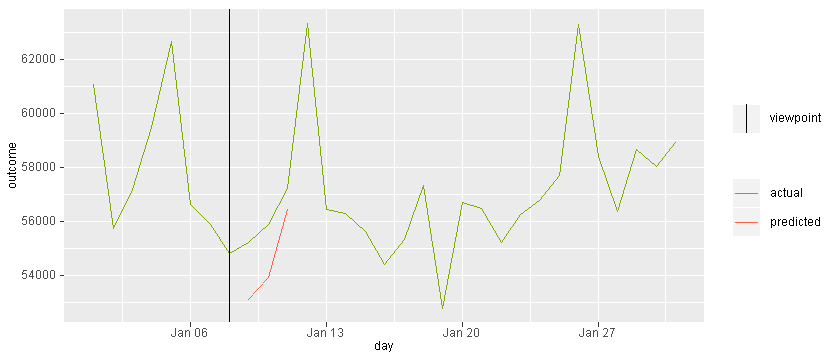

### Recursive Approach

The recursive approach re-uses one model to predict one time step ahead of a moving viewpoint based on previous predictions.

#### Partition Time Series Data for Training & Testing

#### Further Prepare Training Data: Convert from Time Series Form to Cross-Sectional Form

Here we choose these lookbacks and lookaheads:

- lookbacks: 0, 1, 2, 3, 4, 5, 6, 7 days
- lookaheads: 1, 2, 3 days (3 day horizon starting at 1 day ahead)

| observations | variables |
| --- | --- |
| 355 | 12 |

| day | outcome | lookback.1 | lookback.2 | lookback.3 | lookback.4 | lookback.5 | lookback.6 | lookback.7 | lookahead.1 | lookahead.2 | lookahead.3 |
| --- | --- | --- | --- | --- | --- | --- | --- | --- | --- | --- | --- |
| 2013-01-08 | 55542.50 | 57471.34 | 61021.22 | 57717.88 | 56493.22 | 56288.03 | 59471.86 | 58713.65 | 56025.00 | 59837.13 | 59899.84 |
| 2013-01-09 | 56025.00 | 55542.50 | 57471.34 | 61021.22 | 57717.88 | 56493.22 | 56288.03 | 59471.86 | 59837.13 | 59899.84 | 64331.53 |
| 2013-01-10 | 59837.13 | 56025.00 | 55542.50 | 57471.34 | 61021.22 | 57717.88 | 56493.22 | 56288.03 | 59899.84 | 64331.53 | 67181.27 |
| 2013-01-11 | 59899.84 | 59837.13 | 56025.00 | 55542.50 | 57471.34 | 61021.22 | 57717.88 | 56493.22 | 64331.53 | 67181.27 | 65087.37 |
| 2013-01-12 | 64331.53 | 59899.84 | 59837.13 | 56025.00 | 55542.50 | 57471.34 | 61021.22 | 57717.88 | 67181.27 | 65087.37 | 63969.29 |
| 2013-01-13 | 67181.27 | 64331.53 | 59899.84 | 59837.13 | 56025.00 | 55542.50 | 57471.34 | 61021.22 | 65087.37 | 63969.29 | 64918.72 |
| 2013-01-14 | 65087.37 | 67181.27 | 64331.53 | 59899.84 | 59837.13 | 56025.00 | 55542.50 | 57471.34 | 63969.29 | 64918.72 | 65561.24 |
| 2013-01-15 | 63969.29 | 65087.37 | 67181.27 | 64331.53 | 59899.84 | 59837.13 | 56025.00 | 55542.50 | 64918.72 | 65561.24 | 69206.19 |
| 2013-01-16 | 64918.72 | 63969.29 | 65087.37 | 67181.27 | 64331.53 | 59899.84 | 59837.13 | 56025.00 | 65561.24 | 69206.19 | 72263.79 |
| 2013-01-17 | 65561.24 | 64918.72 | 63969.29 | 65087.37 | 67181.27 | 64331.53 | 59899.84 | 59837.13 | 69206.19 | 72263.79 | 73890.93 |
| 2013-01-18 | 69206.19 | 65561.24 | 64918.72 | 63969.29 | 65087.37 | 67181.27 | 64331.53 | 59899.84 | 72263.79 | 73890.93 | 67272.85 |
| 2013-01-19 | 72263.79 | 69206.19 | 65561.24 | 64918.72 | 63969.29 | 65087.37 | 67181.27 | 64331.53 | 73890.93 | 67272.85 | 66812.93 |
| 2013-01-20 | 73890.93 | 72263.79 | 69206.19 | 65561.24 | 64918.72 | 63969.29 | 65087.37 | 67181.27 | 67272.85 | 66812.93 | 65959.22 |
| 2013-01-21 | 67272.85 | 73890.93 | 72263.79 | 69206.19 | 65561.24 | 64918.72 | 63969.29 | 65087.37 | 66812.93 | 65959.22 | 65976.11 |
| 2013-01-22 | 66812.93 | 67272.85 | 73890.93 | 72263.79 | 69206.19 | 65561.24 | 64918.72 | 63969.29 | 65959.22 | 65976.11 | 66247.17 |
| 2013-01-23 | 65959.22 | 66812.93 | 67272.85 | 73890.93 | 72263.79 | 69206.19 | 65561.24 | 64918.72 | 65976.11 | 66247.17 | 63145.95 |
| 2013-01-24 | 65976.11 | 65959.22 | 66812.93 | 67272.85 | 73890.93 | 72263.79 | 69206.19 | 65561.24 | 66247.17 | 63145.95 | 63574.35 |
| 2013-01-25 | 66247.17 | 65976.11 | 65959.22 | 66812.93 | 67272.85 | 73890.93 | 72263.79 | 69206.19 | 63145.95 | 63574.35 | 60822.55 |
| 2013-01-26 | 63145.95 | 66247.17 | 65976.11 | 65959.22 | 66812.93 | 67272.85 | 73890.93 | 72263.79 | 63574.35 | 60822.55 | 57273.14 |
| 2013-01-27 | 63574.35 | 63145.95 | 66247.17 | 65976.11 | 65959.22 | 66812.93 | 67272.85 | 73890.93 | 60822.55 | 57273.14 | 54624.29 |
| 2013-01-28 | 60822.55 | 63574.35 | 63145.95 | 66247.17 | 65976.11 | 65959.22 | 66812.93 | 67272.85 | 57273.14 | 54624.29 | 55568.36 |
| 2013-01-29 | 57273.14 | 60822.55 | 63574.35 | 63145.95 | 66247.17 | 65976.11 | 65959.22 | 66812.93 | 54624.29 | 55568.36 | 56971.58 |
| 2013-01-30 | 54624.29 | 57273.14 | 60822.55 | 63574.35 | 63145.95 | 66247.17 | 65976.11 | 65959.22 | 55568.36 | 56971.58 | 60981.28 |
| 2013-01-31 | 55568.36 | 54624.29 | 57273.14 | 60822.55 | 63574.35 | 63145.95 | 66247.17 | 65976.11 | 56971.58 | 60981.28 | 65594.48 |
| 2013-02-01 | 56971.58 | 55568.36 | 54624.29 | 57273.14 | 60822.55 | 63574.35 | 63145.95 | 66247.17 | 60981.28 | 65594.48 | 57312.05 |
| 2013-02-02 | 60981.28 | 56971.58 | 55568.36 | 54624.29 | 57273.14 | 60822.55 | 63574.35 | 63145.95 | 65594.48 | 57312.05 | 59151.62 |
| 2013-02-03 | 65594.48 | 60981.28 | 56971.58 | 55568.36 | 54624.29 | 57273.14 | 60822.55 | 63574.35 | 57312.05 | 59151.62 | 60346.16 |
| 2013-02-04 | 57312.05 | 65594.48 | 60981.28 | 56971.58 | 55568.36 | 54624.29 | 57273.14 | 60822.55 | 59151.62 | 60346.16 | 60479.83 |
| 2013-02-05 | 59151.62 | 57312.05 | 65594.48 | 60981.28 | 56971.58 | 55568.36 | 54624.29 | 57273.14 | 60346.16 | 60479.83 | 59635.87 |
| 2013-02-06 | 60346.16 | 59151.62 | 57312.05 | 65594.48 | 60981.28 | 56971.58 | 55568.36 | 54624.29 | 60479.83 | 59635.87 | 63199.22 |
| ... | ... | ... | ... | ... | ... | ... | ... | ... | ... | ... | ... |
| 2013-11-29 | 54630.43 | 54880.16 | 56119.14 | 57006.53 | 57526.37 | 61649.89 | 58623.83 | 57257.04 | 57291.40 | 60935.21 | 55786.39 |
| 2013-11-30 | 57291.40 | 54630.43 | 54880.16 | 56119.14 | 57006.53 | 57526.37 | 61649.89 | 58623.83 | 60935.21 | 55786.39 | 56648.96 |
| 2013-12-01 | 60935.21 | 57291.40 | 54630.43 | 54880.16 | 56119.14 | 57006.53 | 57526.37 | 61649.89 | 55786.39 | 56648.96 | 56369.32 |
| 2013-12-02 | 55786.39 | 60935.21 | 57291.40 | 54630.43 | 54880.16 | 56119.14 | 57006.53 | 57526.37 | 56648.96 | 56369.32 | 58791.66 |
| 2013-12-03 | 56648.96 | 55786.39 | 60935.21 | 57291.40 | 54630.43 | 54880.16 | 56119.14 | 57006.53 | 56369.32 | 58791.66 | 57605.49 |
| 2013-12-04 | 56369.32 | 56648.96 | 55786.39 | 60935.21 | 57291.40 | 54630.43 | 54880.16 | 56119.14 | 58791.66 | 57605.49 | 59041.31 |
| 2013-12-05 | 58791.66 | 56369.32 | 56648.96 | 55786.39 | 60935.21 | 57291.40 | 54630.43 | 54880.16 | 57605.49 | 59041.31 | 60012.64 |
| 2013-12-06 | 57605.49 | 58791.66 | 56369.32 | 56648.96 | 55786.39 | 60935.21 | 57291.40 | 54630.43 | 59041.31 | 60012.64 | 55775.26 |
| 2013-12-07 | 59041.31 | 57605.49 | 58791.66 | 56369.32 | 56648.96 | 55786.39 | 60935.21 | 57291.40 | 60012.64 | 55775.26 | 56461.47 |
| 2013-12-08 | 60012.64 | 59041.31 | 57605.49 | 58791.66 | 56369.32 | 56648.96 | 55786.39 | 60935.21 | 55775.26 | 56461.47 | 58122.41 |
| 2013-12-09 | 55775.26 | 60012.64 | 59041.31 | 57605.49 | 58791.66 | 56369.32 | 56648.96 | 55786.39 | 56461.47 | 58122.41 | 57720.91 |
| 2013-12-10 | 56461.47 | 55775.26 | 60012.64 | 59041.31 | 57605.49 | 58791.66 | 56369.32 | 56648.96 | 58122.41 | 57720.91 | 56544.32 |
| 2013-12-11 | 58122.41 | 56461.47 | 55775.26 | 60012.64 | 59041.31 | 57605.49 | 58791.66 | 56369.32 | 57720.91 | 56544.32 | 58209.01 |
| 2013-12-12 | 57720.91 | 58122.41 | 56461.47 | 55775.26 | 60012.64 | 59041.31 | 57605.49 | 58791.66 | 56544.32 | 58209.01 | 60774.12 |
| 2013-12-13 | 56544.32 | 57720.91 | 58122.41 | 56461.47 | 55775.26 | 60012.64 | 59041.31 | 57605.49 | 58209.01 | 60774.12 | 55415.72 |
| 2013-12-14 | 58209.01 | 56544.32 | 57720.91 | 58122.41 | 56461.47 | 55775.26 | 60012.64 | 59041.31 | 60774.12 | 55415.72 | 56425.94 |
| 2013-12-15 | 60774.12 | 58209.01 | 56544.32 | 57720.91 | 58122.41 | 56461.47 | 55775.26 | 60012.64 | 55415.72 | 56425.94 | 56116.10 |
| 2013-12-16 | 55415.72 | 60774.12 | 58209.01 | 56544.32 | 57720.91 | 58122.41 | 56461.47 | 55775.26 | 56425.94 | 56116.10 | 56873.56 |
| 2013-12-17 | 56425.94 | 55415.72 | 60774.12 | 58209.01 | 56544.32 | 57720.91 | 58122.41 | 56461.47 | 56116.10 | 56873.56 | 57155.06 |
| 2013-12-18 | 56116.10 | 56425.94 | 55415.72 | 60774.12 | 58209.01 | 56544.32 | 57720.91 | 58122.41 | 56873.56 | 57155.06 | 60275.93 |
| 2013-12-19 | 56873.56 | 56116.10 | 56425.94 | 55415.72 | 60774.12 | 58209.01 | 56544.32 | 57720.91 | 57155.06 | 60275.93 | 59423.59 |
| 2013-12-20 | 57155.06 | 56873.56 | 56116.10 | 56425.94 | 55415.72 | 60774.12 | 58209.01 | 56544.32 | 60275.93 | 59423.59 | 59945.01 |
| 2013-12-21 | 60275.93 | 57155.06 | 56873.56 | 56116.10 | 56425.94 | 55415.72 | 60774.12 | 58209.01 | 59423.59 | 59945.01 | 59537.74 |
| 2013-12-22 | 59423.59 | 60275.93 | 57155.06 | 56873.56 | 56116.10 | 56425.94 | 55415.72 | 60774.12 | 59945.01 | 59537.74 | 62115.33 |
| 2013-12-23 | 59945.01 | 59423.59 | 60275.93 | 57155.06 | 56873.56 | 56116.10 | 56425.94 | 55415.72 | 59537.74 | 62115.33 | 57845.66 |
| 2013-12-24 | 59537.74 | 59945.01 | 59423.59 | 60275.93 | 57155.06 | 56873.56 | 56116.10 | 56425.94 | 62115.33 | 57845.66 | 57958.12 |
| 2013-12-25 | 62115.33 | 59537.74 | 59945.01 | 59423.59 | 60275.93 | 57155.06 | 56873.56 | 56116.10 | 57845.66 | 57958.12 | 56478.69 |
| 2013-12-26 | 57845.66 | 62115.33 | 59537.74 | 59945.01 | 59423.59 | 60275.93 | 57155.06 | 56873.56 | 57958.12 | 56478.69 | 59480.63 |
| 2013-12-27 | 57958.12 | 57845.66 | 62115.33 | 59537.74 | 59945.01 | 59423.59 | 60275.93 | 57155.06 | 56478.69 | 59480.63 | 58686.81 |
| 2013-12-28 | 56478.69 | 57958.12 | 57845.66 | 62115.33 | 59537.74 | 59945.01 | 59423.59 | 60275.93 | 59480.63 | 58686.81 | 59175.25 |

#### Model

Build a model to predict 1 one time step ahead.

Here we use the linear regression method to build 1 model:

- Model will predict outcome at 1 time step ahead of the viewpoint given outcomes at the viewpoint and across the past 7 time steps.

```r
model = lm(lookahead.1 ~ outcome+lookback.1+lookback.2+lookback.3+lookback.4+lookback.5+lookback.6+lookback.7, datax.train.csx)
```

#### Prepare Views & Predictions

Here we prepare views starting at viewpoint 2014-01-08. Note, we reserve the first 7 days of test data for lookbacks.

| day | outcome | lookback.1 | lookback.2 | lookback.3 | lookback.4 | lookback.5 | lookback.6 | lookback.7 |
| --- | --- | --- | --- | --- | --- | --- | --- | --- |
| 2014-01-08 | 54807.42 | 55872.08 | 56635.26 | 62683.8 | 59471.32 | 57175.36 | 55752.44 | 61084.1 |

Predict outcome at 1 time step ahead of current viewpoint.

| prediction.1 |
| --- |
| 53107.74 |

Prepare a new view (1 time step ahead of the original viewpoint).

Here we prepare a new view at viewpoint 2014-01-09. Use the previous outcome prediction as the outcome at this new viewpoint.

| day | outcome | lookback.1 | lookback.2 | lookback.3 | lookback.4 | lookback.5 | lookback.6 | lookback.7 |
| --- | --- | --- | --- | --- | --- | --- | --- | --- |
| 2014-01-09 | 53107.74 | 54807.42 | 55872.08 | 56635.26 | 62683.8 | 59471.32 | 57175.36 | 55752.44 |

| prediction.2 |
| --- |
| 53803.4 |

Prepare a 2nd new viewpoint (2 days ahead of the original viewpoint).

Here we prepare a new view at viewpoint 2014-01-10. Use the previous 2 outcome predictions as the outcome and 1 time step lookback at this new viewpoint.

| day | outcome | lookback.1 | lookback.2 | lookback.3 | lookback.4 | lookback.5 | lookback.6 | lookback.7 |
| --- | --- | --- | --- | --- | --- | --- | --- | --- |
| 2014-01-10 | 53803.4 | 53107.74 | 54807.42 | 55872.08 | 56635.26 | 62683.8 | 59471.32 | 57175.36 |

| prediction.3 |
| --- |
| 55757.06 |

Compile the outcome predictions.

| day | outcome | outcome.predicted |
| --- | --- | --- |
| 2014-01-01 | 61084.10 | NA |
| 2014-01-02 | 55752.44 | NA |
| 2014-01-03 | 57175.36 | NA |
| 2014-01-04 | 59471.32 | NA |
| 2014-01-05 | 62683.80 | NA |
| 2014-01-06 | 56635.26 | NA |
| 2014-01-07 | 55872.08 | NA |
| 2014-01-08 | 54807.42 | NA |
| 2014-01-09 | 55200.95 | 53107.74 |
| 2014-01-10 | 55887.59 | 53803.40 |
| 2014-01-11 | 57210.81 | 55757.06 |
| 2014-01-12 | 63345.95 | NA |
| 2014-01-13 | 56440.62 | NA |
| 2014-01-14 | 56273.76 | NA |
| 2014-01-15 | 55606.35 | NA |
| 2014-01-16 | 54412.88 | NA |
| 2014-01-17 | 55323.51 | NA |
| 2014-01-18 | 57334.98 | NA |
| 2014-01-19 | 52766.48 | NA |
| 2014-01-20 | 56708.67 | NA |
| 2014-01-21 | 56494.39 | NA |
| 2014-01-22 | 55230.73 | NA |
| 2014-01-23 | 56251.35 | NA |
| 2014-01-24 | 56789.34 | NA |
| 2014-01-25 | 57700.93 | NA |
| 2014-01-26 | 63298.91 | NA |
| 2014-01-27 | 58415.59 | NA |
| 2014-01-28 | 56354.69 | NA |
| 2014-01-29 | 58649.02 | NA |
| 2014-01-30 | 58043.35 | NA |
| 2014-01-31 | 58931.79 | NA |

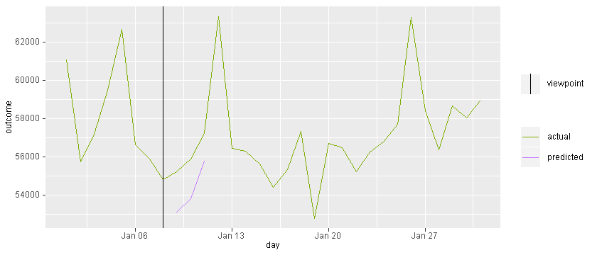

Copyright (c) Berkeley Data Analytics Group, LLC Document revised August 29, 2019